# Spatial Ecology and Macroecology

Practical - Week 4

Melanie Tietje

Department of Spatial Sciences

2026-10-26

# Today

Species Distribution Models I (SDM)

1. Theory: What are SDMs? A short introduction
2. Practical exercise: A simple SDM example

# What are Species Distribution Models?

## SDM overview

- SDM = environmental niche models; can be used to estimate a species’ niche from its distribution
- Predict where species could potentially be located from a limited set of observations – fill in the gaps for a species distribution in an aotherweise sampled area – predict suitability of habitat in a completely different are
- It’s a huge field, mainly used in quantitative ecology and conservation

## SDM overview

- There are multiple software packages and tutorials
- Examples: `sdm`, `dismo`, `usdm`, `ecospat`, `biomod2`, etc
- The earliest modern SDMs date back to the 80s
- It’s a still active field, that quickly changes and advances, and it’s full of problems and challenges

## SDM overview

What data do SDMs require?

1. Georeferenced biodiversity observations
   - Individual locations, species presences, richness, etc
   - Sources: GBIF, OBIS, Movebank, etc. (Practical 1)
2. Geographic layers of environmental data (predictor or independent variable)
   - Climate, land cover, human density, etc
   - Sources: CHELSA, WorldClim, MODIS, etc. (Practical 3)

## SDM overview

How do SDMs work?

SDMs relate the *biodiversity observations* to the *environmental data* using a variety of algorithms

Once this relationship has been modeled, they can predict:

- Future distributions
- Areas where the species might be already
- Areas suitable for (re-)introduction

## SDM applications

1. Finding unknown populations and guiding field surveys

Eyre et al. (2022). Using species distribution models and decision tools to direct surveys and identify potential translocation sites for a critically endangered species. [Diversity and Distributions](https://doi.org/10.1111/ddi.13469)

2. Predicting climate change impacts

Araújo & Rahbek (2006). How does climate change affect biodiversity? [Science](https://doi.org/10.1126/science.1131758)

3. Selecting sites for conservation translocation

Draper et al. (2019). Species distribution models with field validation, a key approach for successful selection of receptor sites in conservation translocations. [Global Ecology and Conservation](https://doi.org/10.1016/j.gecco.2019.e00653)

4. Disease ecology and surveillance

Williams et al. (2015). Climate suitability for European ticks: assessing species distribution models against null models and projection under AR5 climate (2015). [Parasites & Vectors](https://doi.org/10.1186/s13071-015-1046-4)

## Three different SDM approaches

Different SDM algorithms need different types of occurrence data. These are the three main approaches:

1. **Presence-only methods**:
   1. Absence data is not necessary
   2. They can only estimate habitat suitability, not the probability of occurrence
   3. They are sensitive to spatial biases (e.g. unbalanced representation of landcover types)
   4. Example:
      1. MaxEnt

## SDM approaches

2. **Presence-absence methods**:
   1. Use presence-absence data
   2. Estimate true probability of occurrence
   3. Sensitive to imperfect detection
   4. Examples:
      1. Regression-based methods: Generalized Linear models (GLM), Generalized Additive Models (GAM)
      2. Machine-learning methods: Random forest (RT), Boosted Regression Trees (BRT)

## SDM approaches

3. **Presence-pseudo absence methods:**
   1. Generate artificial absences to allow using **presence-absence methods**
      1. The [Barbet-Massin et al. (2012) paper](https://besjournals.onlinelibrary.wiley.com/doi/10.1111/j.2041-210X.2011.00172.x) is a good starting point on how to generate them
   2. Allows using modelling approaches that require presence-absence data
   3. Example: GLM, Random forest (and other presence-absence methods)

## SDM approaches

4. **Ensemble methods:**

If we can build many models with different algorithms / strategies, which one do we choose?

- We could choose the one that’s best suited to our data, or that performs the best
- However, a more popular approach is performing ensemble models
- In this approach, predictions from multiple models are combined or averaged to produce a single model
- The most frequently used package is `biomod2`

## SDM workflow

ODMAP protocol ([Zurell et al. 2020](https://onlinelibrary.wiley.com/doi/full/10.1111/ecog.04960))

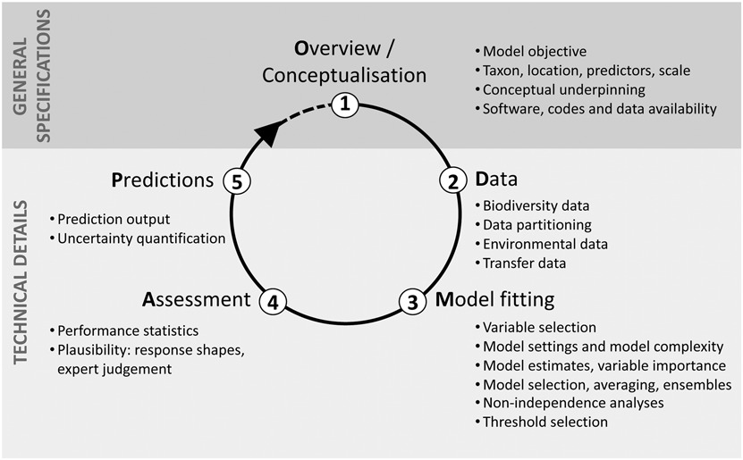

## SDM workflow - Overview / Conceptualization

Which are our research objectives?

Which taxa are we working with? Where is our location? And our scale?

What data is available?

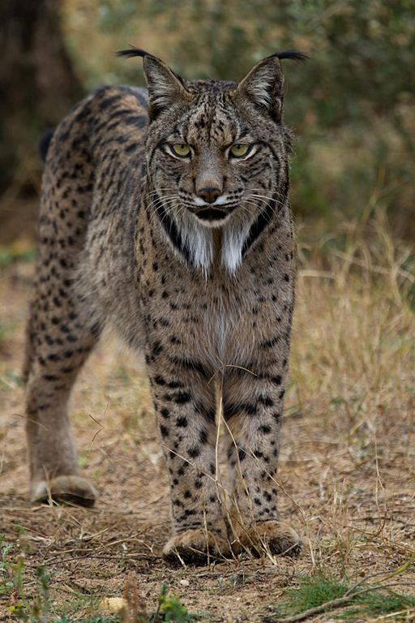

[interactive chart not shown]

## SDM workflow - Get data

Obtain:

- Biodiversity data (generally point observations)
- Environmental data (generally rasters)

```
|---------|---------|---------|---------|
=========================================
```

[interactive chart not shown]

## SDM workflow - Check & clean data

Ensure the temporal and spatial scale of the biodiversity and environmental data match

Clean biodiversity data of unreliable observations - centroids - outliers - duplicates - institutions

[interactive chart not shown]

## SDM workflow - Create pseudoabsences

Generate pseudo-absences (if necessary, we will do that here)

[interactive chart not shown]

## SDM workflow - Check environmental variables for collinearity

Like with most models, collinearity can create problems: test and remove if necessary.

```
12 variables from the 19 input variables have collinearity problem:

wc2.1_30s_bio_16 wc2.1_30s_bio_17 wc2.1_30s_bio_19 wc2.1_30s_bio_18 wc2.1_30s_bio_6 wc2.1_30s_bio_4 wc2.1_30s_bio_12 wc2.1_30s_bio_1 wc2.1_30s_bio_5 wc2.1_30s_bio_7 wc2.1_30s_bio_10 wc2.1_30s_bio_15

After excluding the collinear variables, the linear correlation coefficients ranges between:
min correlation ( wc2.1_30s_bio_9 ~ wc2.1_30s_bio_8 ):  0.02494611
max correlation ( wc2.1_30s_bio_13 ~ wc2.1_30s_bio_2 ):  -0.6230385

---------- VIFs of the remained variables --------
         Variables      VIF
1  wc2.1_30s_bio_2 3.611121
2  wc2.1_30s_bio_3 2.498661
3  wc2.1_30s_bio_8 2.928519
4  wc2.1_30s_bio_9 2.508456
5 wc2.1_30s_bio_11 6.802107
6 wc2.1_30s_bio_13 2.591154
7 wc2.1_30s_bio_14 3.076643
```

## SDM workflow - Data preparation

Remove collinear environmental variables

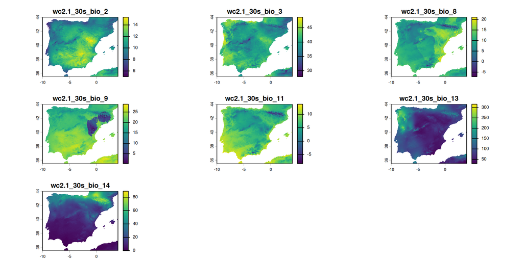

## SDM workflow - Model fitting & evaluation

Do the results make sense?

1. Exploration of response curves
2. Assessment of model coefficients and variable importance

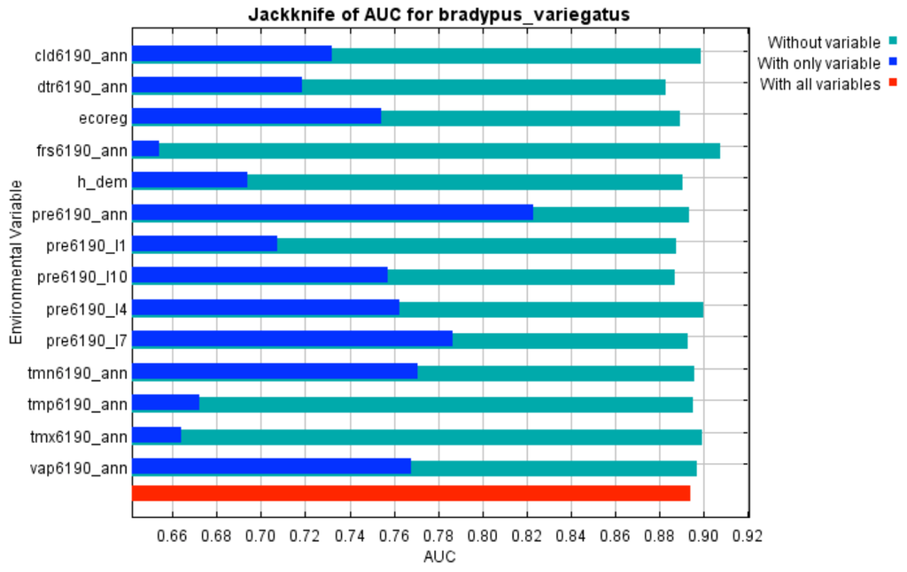

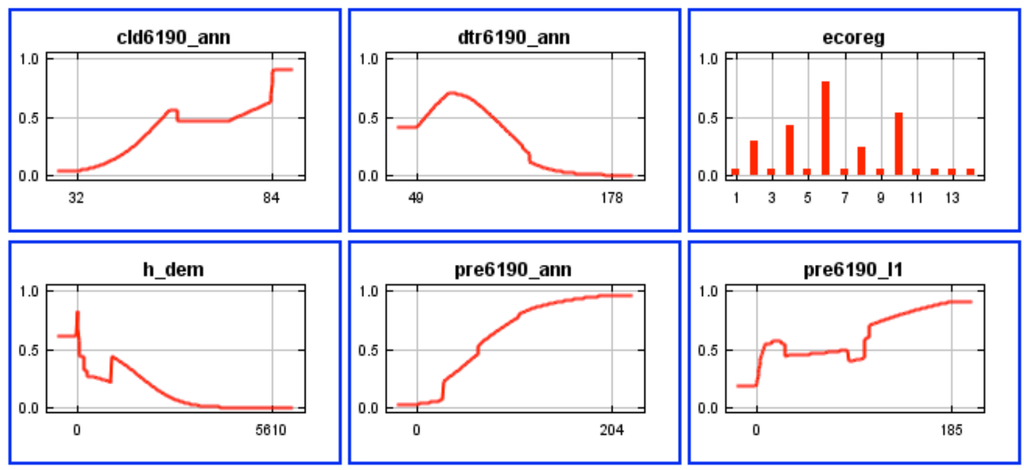

## SDM workflow - Model evaluation

Examples for model performance metrics:

- AUC: the closer to 1 the better, but beware! very high values can indicate overfitting
- TSS: true skill statistic
- Sensitivity: true positive rate
- Specificity: true negative rate

–> You want to balance the correctly predicted presences and correctly predicted absences, depending on what your goal is

## SDM workflow - Maps

Map the potential distribution obtained from the model

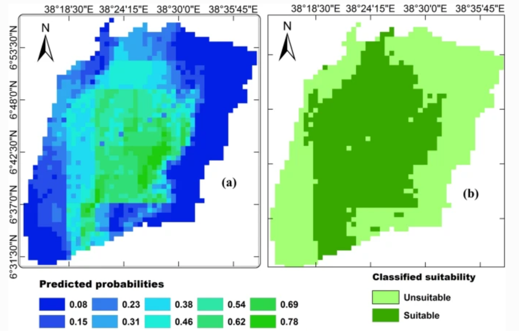

## Limitations

Underlying assumptions:

- Species are at equilibrium with the environment
- Species and environment are well sampled: no spatial bias, all areas covered
- We are consider all factors determining species distributions: choose the variables that matter for a species!

## Resources: Tutorials

- [Introduction to species distribution modelling (SDM) in R](https://damariszurell.github.io/SDM-Intro/) *by Damaris Zurell*
- [Species distribution modelling practicals (Macroecology and global change course)](https://damariszurell.github.io/EEC-MGC/b1_SpeciesData.html) *by Damaris Zurell*
- ENM2020: A Free Online Course and Set of Resources on Modeling Species’ Niches and Distributions *led by Town Peterson* ([Youtube playlist](https://www.youtube.com/playlist?list=PLhEJuWmv8Jf67qSdifDvgOk5DOJsNNiam), [Schedule and PDFs](https://docs.google.com/spreadsheets/d/1RQu1XRKyYfrnFI2V1g677d0sf8tFxC2xUvb96cbP02s/edit?usp=sharing), [Publication](https://journals.ku.edu/jbi/article/view/15016))
- [Best Practices in Spacies Distribution Modeling: A workshop in R](http://www.earthskysea.org/best-practices-in-species-distribution-modeling-a-workshop-in-r/) *by Adam Smith*
- [Species distribution modeling in R](https://rspatial.org/raster/sdm/index.html) *by Robert Hijmans and Jane Elith*
- [A very brief introduction to species distribution models in R](https://jcoliver.github.io/learn-r/011-species-distribution-models.html) *by Jeff Oliver*
- [SDM course](https://github.com/bobmuscarella/SDM-course) *by Bob Muscarella* (very useful for finding other resources!)
- [SDM course](https://www.youtube.com/watch?v=obuMW5NAtJE) *by Richard Pearson at UCL*

# Let’s make an SDM!

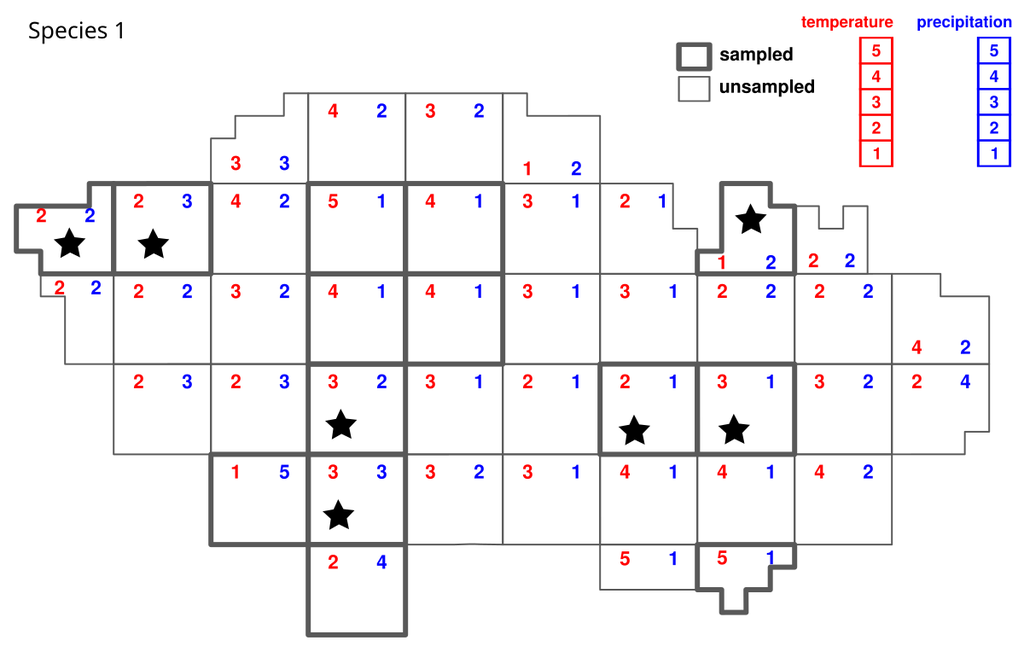